# Water Data Preparation for CDC Data Call Spring 2025

# Start

This write-up documents the processing steps in preparing the summary water data for submission to the spring 2025 Data Call. This follows the How-to-Guide and Data Dictionary 2025. To get an understanding of names and/or rules please refer to those documents. The process was started with the unaggregated file(.xlsx) received from NDEE on 3/31/2025. That contained 12,472 rows of data. Both sampling data and PWS Inventory were validated using the Python codes. 27 of the PWS inventories had validation errors of not containing values for Latitude, Longitude, and LocationDerivationCode (included them in the PWSInventory_2025_errors.csv file attached to the same email. Their related values were replaced for ‘Missing’ values following HTG Guide 2025.

`['PWSIDNumber', 'Year', 'AnalyteName', 'AnalyteCode', 'ConcentrationUnits', 'Concentration', 'DateSampled', 'SamplePointID', 'DetectionLimit', 'DetectionLimitUom', 'NonDetectFlag']`

It contains sampling results from 2023 to 2024 as below:

| Year | Rows of data |
| --- | --- |
| 2023 | 5796 |
| 2024 | 6676 |

- **Step 1-** Adjusting AnalyteCode All data for Analytedoe 1041 removed, since not required by data call (0 rows).
- **Step 2 -** Initial validation test An initial validation against Data Dictionary rules done on columns that will be present in the final summary file. all passed validation for the following columns: ‘RowIdentifier’, ‘PWSIDNumber’, ‘Year’, ‘AnalyteCode’, ‘ConcentrationUnits’, ‘Concentration’, ‘DateSampled’]

After these intial steps number of data points bsed on each AnalyteCode are as below:

| AnalyteCode | No. Rows |
| --- | --- |
| 1038 | 4496 |
| 1005 | 1259 |
| 2050 | 1193 |
| 2039 | 1193 |
| 2987 | 1006 |
| 2984 | 1006 |
| 2950 | 682 |
| 2456 | 682 |
| 4010 | 747 |
| 4006 | 208 |

- **Step 3 -** Checked if the ConcentrationUnits for each AnalyteCode applies with the values in the Data Dictionary

All the units used are correct. Note: There is no code nitrate (1040). However, the 2024 allows using code 1038, therefore we did not change it.

- **Step 4 -** Checked if uranium needs a change of ConcentrationUnits from pci/l to ug/l
- **Step 4 -** Checking rows with NonDetectFlag. Below is the result for checking rows with a NonDetectionFlag = 1. All of them have a half LDL value for their concentrations, which follows the HTG Guide.

| is_half_LDL | number |
| --- | --- |
| 0.5 | 5236 |

Below is the percentage of non-detects of sampling for each analyte.

```
[1] "Percent of no-detect flags for each analyte:"
```

[output not shown]

- **Step 5 -** Averaged duplicates into one values. Checked for duplicated of same analyte sampled in the same day from same point location, and averaged them into one value. It contained repeatitions for values in columns (PWSIDNumber, Year, AnalyteCode, DateSampled, SamplePointID). Added a new column “NumSamples” that can account for these number of samples. (The highest was 12 for several analyte sampling in the same point in the same date)

```
[1] "initial rows in data:  12472"
[1] "no. of rows after averaging same day/point/analyte:  11772"
```

before starting the summarization, we took a look into maximum concentration value for each analyte compared to its median over all dataset.For each maximum value, its DateSampled is also provided.

| AnalyteCode | maximum | median | DateSampled |
| --- | --- | --- | --- |
| 1005 | 18.400 | 3.500 | 2023-03-20 |
| 1038 | 18.600 | 3.880 | 2023-04-17 |
| 2039 | 8.910 | 1.000 | 2023-04-12 |
| 2050 | 0.326 | 0.040 | 2024-05-22 |
| 2456 | 62.800 | 10.600 | 2023-03-06 |
| 2950 | 156.000 | 33.100 | 2024-07-15 |
| 2984 | 2.250 | 0.250 | 2023-05-24 |
| 2987 | 3.780 | 0.250 | 2023-10-16 |
| 4006 | 81.056 | 19.817 | 2024-02-20 |
| 4010 | 7.120 | 0.862 | 2024-11-12 |

- Below, we have also provided plots for the distributions: Based on the diagrams we suggest a look into analytes 2039, 2050, 2984, and 2987 since they have very large outliers.

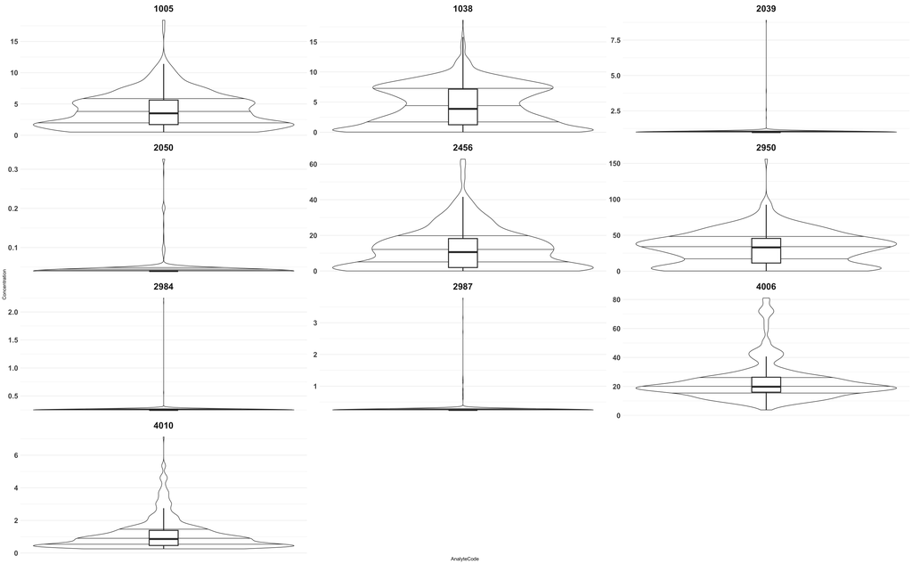

## Starting the Summarization

- **Step S.1 -** Summarized annual means for the 8 anlytes following HTG 2025:

| Year | NuLocations | NuSamples | Analytes | Non_detects |
| --- | --- | --- | --- | --- |
| 2023 | 3918 | 5122 | 8 | 2324 |
| 2024 | 4461 | 5986 | 8 | 2884 |

- **Step S.2 -** Summarized annual means for the two Disinfection By-products following HTG 2025:

..

| Year | NuLocations | NuSamples | Analytes | Non_detects |
| --- | --- | --- | --- | --- |
| 2023 | 386 | 674 | 2 | 16 |
| 2024 | 404 | 690 | 2 | 12 |

- **Step S.3 -** Summarized annual maximums for all the analytes following HTG 2025:

…

| Year | NuLocations | NuSamples | Analytes | Non_detects |
| --- | --- | --- | --- | --- |
| 2023 | 4140 | 5796 | 10 | 2340 |
| 2024 | 4687 | 6676 | 10 | 2896 |

- **Step S.4 -** Summarized quarterly means for all the analytes following HTG 2025: We first separatd the four analytes for which the quarterly values are required. Nitrate and Atrazine and disinfection-by-products (TTHM and HAA5). Then for each group, since the methods are different and similar to their annual averages, we calculated the average quarterly values

… * **Step S.4.1 -** For Atrazine and Nitrate

…

| SummaryTimePeriod | NuLocations | NuSamples | Analytes | Non_detects |
| --- | --- | --- | --- | --- |
| 2023-1 | 761 | 777 | 2 | 160 |
| 2023-2 | 641 | 654 | 2 | 165 |
| 2023-3 | 612 | 633 | 2 | 138 |
| 2023-4 | 588 | 596 | 2 | 131 |
| 2024-1 | 733 | 743 | 2 | 180 |
| 2024-2 | 810 | 837 | 2 | 296 |
| 2024-3 | 751 | 789 | 2 | 300 |
| 2024-4 | 650 | 660 | 2 | 177 |

- **Step S.4.1 -** For disinfection by-products

….

| SummaryTimePeriod | NuLocations | NuSamples | Analytes | Non_detects |
| --- | --- | --- | --- | --- |
| 2023-1 | 56 | 124 | 2 | 2 |
| 2023-2 | 62 | 122 | 2 | 1 |
| 2023-3 | 212 | 308 | 2 | 13 |
| 2023-4 | 56 | 120 | 2 | 0 |
| 2024-1 | 56 | 120 | 2 | 1 |
| 2024-2 | 60 | 122 | 2 | 0 |
| 2024-3 | 220 | 314 | 2 | 9 |
| 2024-4 | 68 | 134 | 2 | 2 |

- **Step F -** Then the all resulted 5 tables were aggreagated into one table in conformance with HTG and Data Dictionary 2025

As the final step, we checked the data against the 8 steps in the Gateway 2022 (Appendix F of HTG)